# HW10

Claire

2019年6月6日

### 空間分析 HW 10

#### 地理二 b06208028 甘佳昀

```r
library(spdep)
library(rgdal)
library(GISTools)

Tainan_li <- readOGR(dsn = '.', layer = "Tainan_li", encoding="utf8")
Tainan_town <- readOGR(dsn = '.', layer = "Tainan_town", encoding="utf8")
School <- readOGR(dsn = ".", layer = "Schools", encoding="utf8")
Tainan_li$all_school<-poly.counts(School,Tainan_li)
li_count<-Tainan_li$all_school
Tainan_li$school_density<-poly.counts(School,Tainan_li)/poly.areas(Tainan_li)*10^6
school_density<-Tainan_li$school_density
```

### 村里學校總數LISA

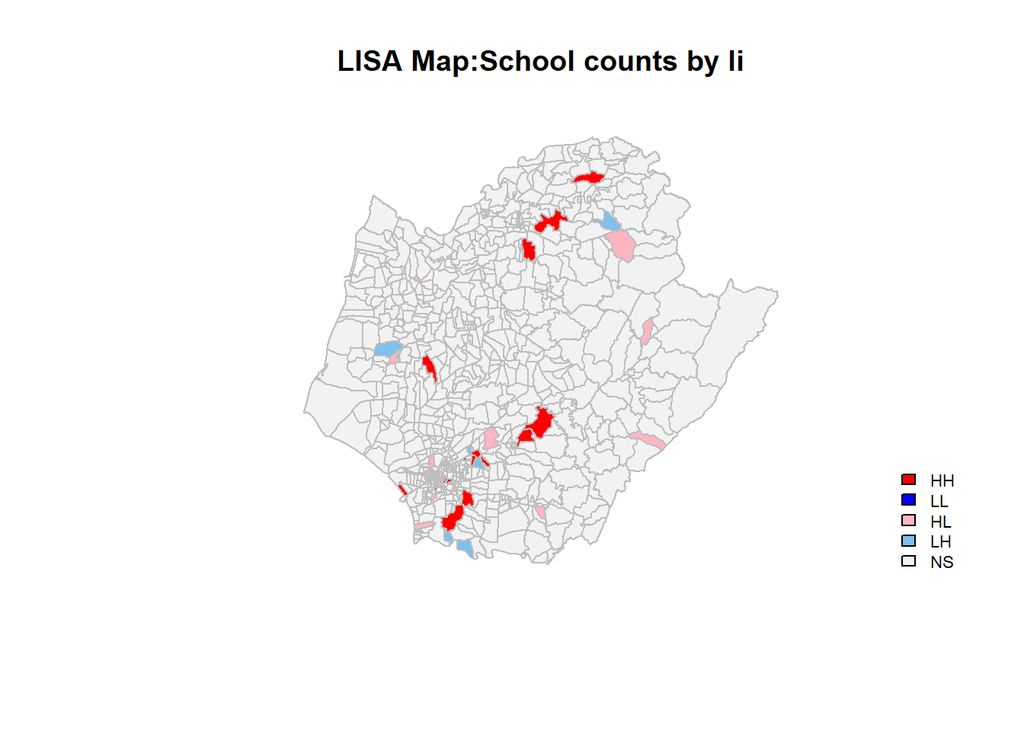

```r
TN_nb<-poly2nb(Tainan_li)
TN_nb_w<- nb2listw(TN_nb, zero.policy=T)# 2. Building Weighting Matrix
LISA <- localmoran(Tainan_li$all_school, TN_nb_w, zero.policy=T,alternative = 'two.sided')
diff = li_count - mean(li_count) # diff看自己和平均比起來算是H還是L
z = LISA[,4]
quad = c()
quad[diff>0 & z>0] = 1 # H-H
quad[diff<0 & z>0] = 2 # L-L
quad[diff>0 & z<0] = 3 # H-L
quad[diff<0 & z<0] = 4 # L-H
quad[LISA[, 5]>0.05]=5 # 不顯著，設定雙尾所以用0.05比較就可以
colors=c("red", "blue", "lightpink", "skyblue2", rgb(.95, .95, .95))
plot(Tainan_li, border="grey", col=colors[quad], main = "LISA Map:School counts by li")
legend("bottomright",legend=c("HH","LL","HL","LH","NS"),fill=colors,bty="n",cex=0.7,y.intersp=1,x.intersp=1)
```

### 村里學校總數Gi*

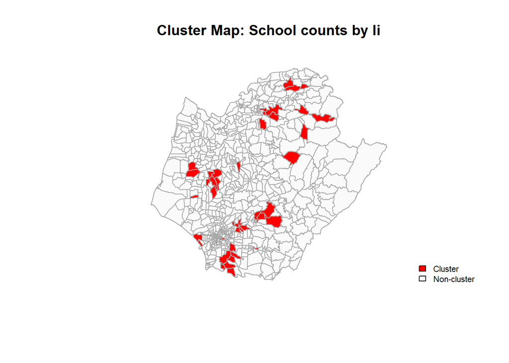

```r
#村里學校總數

TN_nb<-poly2nb(Tainan_li)
TN_nb_in<-include.self(TN_nb);#把自己加進去
TN_nb_in_w<- nb2listw(TN_nb_in, zero.policy=T)
LG.li<-localG(li_count, TN_nb_in_w)
LG1.li<-0
for (i in 1:800){LG1.li[i]<-LG.li[i]}
Tainan_li$LG<-LG1.li

# Mapping Hotspot Areas (using Local Gi*, p < 0.05)
LGV<-Tainan_li$LG
chk<-LGV-1.65

quadrant <- vector(mode="numeric",length=800)
quadrant[chk>0] <- 1 # Cluster
quadrant[chk<0] <- 2 # Non-cluster

colors <- c("red", "gray98")
plot(Tainan_li, border="darkgrey", col=colors[quadrant], main = "Cluster Map: School counts by li")
legend("bottomright",legend=c("Cluster","Non-cluster"), fill=colors,bty="n",cex=0.7,y.intersp=1,x.intersp=1)
```

### 村里學校密度LISA

[figure not shown]

```r
TN_nb.d<-poly2nb(Tainan_li)
TN_nb_w.d<- nb2listw(TN_nb.d, zero.policy=T)# 2. Building Weighting Matrix
LISA <- localmoran(Tainan_li$school_density, TN_nb_w.d, zero.policy=T,alternative = 'two.sided')
diff = school_density - mean(school_density) # diff看自己和平均比起來算是H還是L
z = LISA[,4]
quad = c()
quad[diff>0 & z>0] = 1 # H-H
quad[diff<0 & z>0] = 2 # L-L
quad[diff>0 & z<0] = 3 # H-L
quad[diff<0 & z<0] = 4 # L-H
quad[LISA[, 5]>0.05]=5 # 不顯著，設定雙尾所以用0.05比較就可以
colors=c("red", "blue", "lightpink", "skyblue2", rgb(.95, .95, .95))
plot(Tainan_li, border="grey", col=colors[quad], main = "LISA Map:School counts by li")
legend("bottomright",legend=c("HH","LL","HL","LH","NS"),fill=colors,bty="n",cex=0.7,y.intersp=1,x.intersp=1)
```

### 村里學校密度Gi*

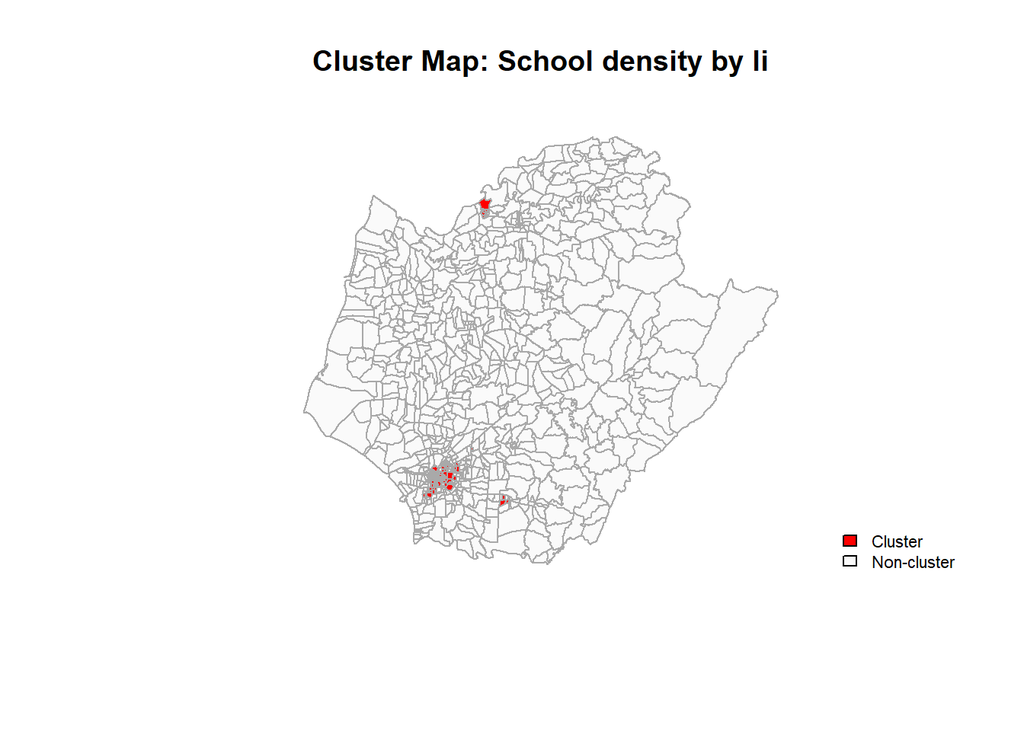

```r
#村里學校密度

TN_nb.d<-poly2nb(Tainan_li)
TN_nb_in.d<-include.self(TN_nb.d);#把自己加進去
TN_nb_in_w.d<- nb2listw(TN_nb_in.d, zero.policy=T)
LG.li.d<-localG(school_density, TN_nb_in_w.d)

LG1.li.d<-0
for (i in 1:800){LG1.li.d[i]<-LG.li.d[i]}
Tainan_li$LG.d<-LG1.li.d

# Mapping Hotspot Areas (using Local Gi*, p < 0.05)
LGV.d<-Tainan_li$LG.d
chk.d<-LGV.d-1.65

quadrant <- vector(mode="numeric",length=800)
quadrant[chk.d>0] <- 1 # Cluster
quadrant[chk.d<0] <- 2 # Non-cluster

colors <- c("red", "gray98")
plot(Tainan_li, border="darkgrey", col=colors[quadrant], main = "Cluster Map: School density by li")
legend("bottomright",legend=c("Cluster","Non-cluster"), fill=colors,bty="n",cex=0.7,y.intersp=1,x.intersp=1)
```

### 鄉鎮學校總數LISA

[figure not shown]

```r
Tainan_town$all_school<-poly.counts(School,Tainan_town)
town_count<-Tainan_town$all_school

TN_nb.t<-poly2nb(Tainan_town)
TN_nb_w.t<- nb2listw(TN_nb.t, zero.policy=T)# 2. Building Weighting Matrix
LISA <- localmoran(Tainan_town$all_school, TN_nb_w.t, zero.policy=T,alternative = 'two.sided')
diff = town_count - mean(town_count) # diff看自己和平均比起來算是H還是L
z = LISA[,4]
quad = c()
quad[diff>0 & z>0] = 1 # H-H
quad[diff<0 & z>0] = 2 # L-L
quad[diff>0 & z<0] = 3 # H-L
quad[diff<0 & z<0] = 4 # L-H
quad[LISA[, 5]>0.05]=5 # 不顯著，設定雙尾所以用0.05比較就可以
colors=c("red", "blue", "lightpink", "skyblue2", rgb(.95, .95, .95))
plot(Tainan_town, border="grey", col=colors[quad], main = "LISA Map:School counts by li")
legend("bottomright",legend=c("HH","LL","HL","LH","NS"),fill=colors,bty="n",cex=0.7,y.intersp=1,x.intersp=1)
```

### 鄉鎮學校總數Gi*

[figure not shown]

```r
#鄉鎮學校總數
TN_nb_in.t<-include.self(TN_nb.t);#把自己加進去
TN_nb_in_w.t<- nb2listw(TN_nb_in.t, zero.policy=T)
LG.li.t<-localG(town_count, TN_nb_in_w.t)

LG1.li.t<-0
for (i in 1:38){LG1.li.t[i]<-LG.li.t[i]}
Tainan_town$LG.t<-LG1.li.t

# Mapping Hotspot Areas (using Local Gi*, p < 0.05)
LGV<-Tainan_town$LG.t
chk<-LGV-1.65

quadrant <- vector(mode="numeric",length=38)
quadrant[chk>0] <- 1 # Cluster
quadrant[chk<0] <- 2 # Non-cluster

colors <- c("red", "gray98")
plot(Tainan_town, border="darkgrey", col=colors[quadrant], main = "Cluster Map: School counts by li")
legend("bottomright",legend=c("Cluster","Non-cluster"), fill=colors,bty="n",cex=0.7,y.intersp=1,x.intersp=1)
```

#### 分析：

##### 在使用Gi*畫出熱點地圖方面，發現以村里為單位的學校總數畫出的熱點地圖相較於用其他參數畫出的圖中為熱點的polygon是最多的。推測是因為村里界的polygon較破碎且多，而且計算總數的差異會比用面積校正過的差異還來得大。至於在學校密度方面，熱區看起來是最不顯著的，而且大多集中在南邊一處里界切割的很破碎細小的地方。而從鄉鎮學校總數來看，除了南部的熱區跟前面兩張圖有所重疊外，還多了西邊一塊熱區。此外能觀察出在Lisa的HH大多數也會出現在Gi*的熱區範圍中，但Gi*的熱區不一定會出現在Lisa的HH範圍中，我認為那是因為Lisa的計算與判斷方式有個NS(不顯著)的區間，而Gi*沒有。